# Biostat 203B Homework 5

Due Mar 22 @ 11:59PM

Author

Zehan Hu

## Predicting ICU duration

Using the ICU cohort `mimiciv_icu_cohort.rds` you built in Homework 4, develop at least three machine learning approaches (logistic regression with enet regularization, random forest, boosting, SVM, MLP, etc) plus a model stacking approach for predicting whether a patient’s ICU stay will be longer than 2 days. You should use the `los_long` variable as the outcome. You algorithms can use patient demographic information (gender, age at ICU `intime`, marital status, race), ICU admission information (first care unit), the last lab measurements before the ICU stay, and first vital measurements during ICU stay as features. You are welcome to use any feature engineering techniques you think are appropriate; but make sure to not use features that are not available at an ICU stay’s `intime`. For instance, `last_careunit` cannot be used in your algorithms.

1. Data preprocessing and feature engineering.

```r
library(GGally)
library(gtsummary)
library(ranger)
library(tidyverse)
library(tidymodels)
library(ISLR2)
library(vip)
library(rpart.plot)
```

```r
mimiciv_icu_cohort<-readRDS("../hw4/mimiciv_shiny/mimic_icu_cohort.rds")
```

```r
mimiciv_icu_cohort <- mimiciv_icu_cohort |>
  select(subject_id, hadm_id, stay_id,
         "Non Invasive Blood Pressure diastolic"=
           "as.numeric(\"Non Invasive Blood Pressure diastolic\")",
         "Non Invasive Blood Pressure systolic"=
           "as.numeric(\"Non Invasive Blood Pressure systolic\")",
         "Heart Rate"="as.numeric(`Heart Rate`)",
         temperature_fahrenheit="as.numeric(`Temperature Fahrenheit`)",
         los_long,
         insurance,
         language,
         marital_status,
         race,
         hospital_expire_flag,
         gender,
         sodium,
         chloride,
         creatinine,
         potassium,
         glucose,
         hematocrit,
         wbc,
         bicarbonate)
```

```r
# Assuming your data frame is named df

# Convert all character columns to factors
mimiciv_icu_cohort[] <- lapply(mimiciv_icu_cohort,
                               function(x) if(is.character(x)) factor(x) else x)

mimiciv_icu_cohort$los_long<-as.factor(mimiciv_icu_cohort$los_long)
```

2. Partition data into 50% training set and 50% test set. Stratify partitioning according to `los_long`. For grading purpose, sort the data by `subject_id`, `hadm_id`, and `stay_id` and use the seed `203` for the initial data split. Below is the sample code.
3. Train and tune the models using the training set.
4. Compare model classification performance on the test set. Report both the area under ROC curve and accuracy for each machine learning algorithm and the model stacking. Interpret the results. What are the most important features in predicting long ICU stays? How do the models compare in terms of performance and interpretability?

```r
set.seed(203)

# sort
mimiciv_icu_cohort <- mimiciv_icu_cohort |>
  arrange(subject_id, hadm_id, stay_id)

data_split <- initial_split(
  mimiciv_icu_cohort,
  # stratify by los_long
  strata = "los_long",
  prop = 0.5
  )
```

```r
mimic_other <- training(data_split)%>%
  select(-subject_id, -hadm_id, -stay_id)

dim(mimic_other)
```

```
[1] 36590    19
```

```r
mimic_test<-testing(data_split)%>%
  select(-subject_id, -hadm_id, -stay_id)
dim(mimic_test)
```

```
[1] 36591    19
```

```r
sapply(mimic_other, class)
```

```
Non Invasive Blood Pressure diastolic  Non Invasive Blood Pressure systolic
                            "numeric"                             "numeric"
                           Heart Rate                temperature_fahrenheit
                            "numeric"                             "numeric"
                             los_long                             insurance
                             "factor"                              "factor"
                             language                        marital_status
                             "factor"                              "factor"
                                 race                  hospital_expire_flag
                             "factor"                             "integer"
                               gender                                sodium
                             "factor"                             "numeric"
                             chloride                            creatinine
                            "numeric"                             "numeric"
                            potassium                               glucose
                            "numeric"                             "numeric"
                           hematocrit                                   wbc
                            "numeric"                             "numeric"
                          bicarbonate
                            "numeric"
```

```r
norm_recipe <-
  recipe(
    los_long ~ .,
    data = mimic_other
  ) %>%
  step_impute_mean(all_numeric(), -all_outcomes()) %>%
  # Impute categorical variables using KNN or another appropriate method
  step_impute_knn(all_nominal(), -all_outcomes()) %>%
  # Convert all nominal variables to dummy variables, excluding the outcome
  step_dummy(all_nominal(), -all_outcomes()) %>%
  # Remove zero variance predictors
  step_zv(all_numeric_predictors()) %>%
  # Normalize all numeric predictors
  step_normalize(all_numeric_predictors())


norm_recipe
```

```
── Recipe ──────────────────────────────────────────────────────────────────────
```

```
── Inputs
```

```
Number of variables by role
```

```
outcome:    1
predictor: 18
```

```
── Operations
```

```
• Mean imputation for: all_numeric() and -all_outcomes()
```

```
• K-nearest neighbor imputation for: all_nominal() and -all_outcomes()
```

```
• Dummy variables from: all_nominal() and -all_outcomes()
```

```
• Zero variance filter on: all_numeric_predictors()
```

```
• Centering and scaling for: all_numeric_predictors()
```

### Random Forest

```r
rf_mod <-
  rand_forest(
    mode = "classification",
    # Number of predictors randomly sampled in each split
    mtry = tune(),
    # Number of trees in ensemble
    trees = tune()
  ) %>%
  set_engine("ranger", importance="impurity")%>%
set_mode("classification")
rf_mod
```

```
Random Forest Model Specification (classification)

Main Arguments:
  mtry = tune()
  trees = tune()

Engine-Specific Arguments:
  importance = impurity

Computational engine: ranger
```

```r
rf_wf <- workflow() %>%
  add_recipe(norm_recipe) %>%
  add_model(rf_mod)
rf_wf
```

```
══ Workflow ════════════════════════════════════════════════════════════════════
Preprocessor: Recipe
Model: rand_forest()

── Preprocessor ────────────────────────────────────────────────────────────────
5 Recipe Steps

• step_impute_mean()
• step_impute_knn()
• step_dummy()
• step_zv()
• step_normalize()

── Model ───────────────────────────────────────────────────────────────────────
Random Forest Model Specification (classification)

Main Arguments:
  mtry = tune()
  trees = tune()

Engine-Specific Arguments:
  importance = impurity

Computational engine: ranger
```

```r
param_grid <- grid_regular(
  trees(range = c(100L, 300L)),
  mtry(range = c(1L, 5L)),
  levels = c(3, 5)
  )
param_grid
```

```
# A tibble: 15 × 2
   trees  mtry
   <int> <int>
 1   100     1
 2   200     1
 3   300     1
 4   100     2
 5   200     2
 6   300     2
 7   100     3
 8   200     3
 9   300     3
10   100     4
11   200     4
12   300     4
13   100     5
14   200     5
15   300     5
```

```r
set.seed(203)

folds <- vfold_cv(mimic_other, v = 5)
folds
```

```
#  5-fold cross-validation
# A tibble: 5 × 2
  splits               id
  <list>               <chr>
1 <split [29272/7318]> Fold1
2 <split [29272/7318]> Fold2
3 <split [29272/7318]> Fold3
4 <split [29272/7318]> Fold4
5 <split [29272/7318]> Fold5
```

```r
rf_fit <- rf_wf %>%
  tune_grid(
    resamples = folds,
    grid = param_grid,
    metrics = metric_set(roc_auc, accuracy)
    )
```

[output not shown]

[output not shown]

[output not shown]

[output not shown]

[output not shown]

[output not shown]

[output not shown]

[output not shown]

[output not shown]

[output not shown]

[output not shown]

[output not shown]

[output not shown]

[output not shown]

[output not shown]

[output not shown]

[output not shown]

```r
rf_fit
```

```
# Tuning results
# 5-fold cross-validation
# A tibble: 5 × 4
  splits               id    .metrics          .notes
  <list>               <chr> <list>            <list>
1 <split [29272/7318]> Fold1 <tibble [30 × 6]> <tibble [16 × 3]>
2 <split [29272/7318]> Fold2 <tibble [0 × 6]>  <NULL>
3 <split [29272/7318]> Fold3 <tibble [0 × 6]>  <NULL>
4 <split [29272/7318]> Fold4 <tibble [0 × 6]>  <NULL>
5 <split [29272/7318]> Fold5 <tibble [0 × 6]>  <NULL>

There were issues with some computations:

  - Warning(s) x16: skipping variable with zero or non-finite range.

Run `show_notes(.Last.tune.result)` for more information.
```

```
# A tibble: 30 × 8
    mtry trees .metric  .estimator  mean     n std_err .config
   <int> <int> <chr>    <chr>      <dbl> <int>   <dbl> <chr>
 1     1   100 accuracy binary     0.570     1      NA Preprocessor1_Model01
 2     1   100 roc_auc  binary     0.602     1      NA Preprocessor1_Model01
 3     1   200 accuracy binary     0.571     1      NA Preprocessor1_Model02
 4     1   200 roc_auc  binary     0.602     1      NA Preprocessor1_Model02
 5     1   300 accuracy binary     0.573     1      NA Preprocessor1_Model03
 6     1   300 roc_auc  binary     0.602     1      NA Preprocessor1_Model03
 7     2   100 accuracy binary     0.574     1      NA Preprocessor1_Model04
 8     2   100 roc_auc  binary     0.605     1      NA Preprocessor1_Model04
 9     2   200 accuracy binary     0.572     1      NA Preprocessor1_Model05
10     2   200 roc_auc  binary     0.603     1      NA Preprocessor1_Model05
# ℹ 20 more rows
```

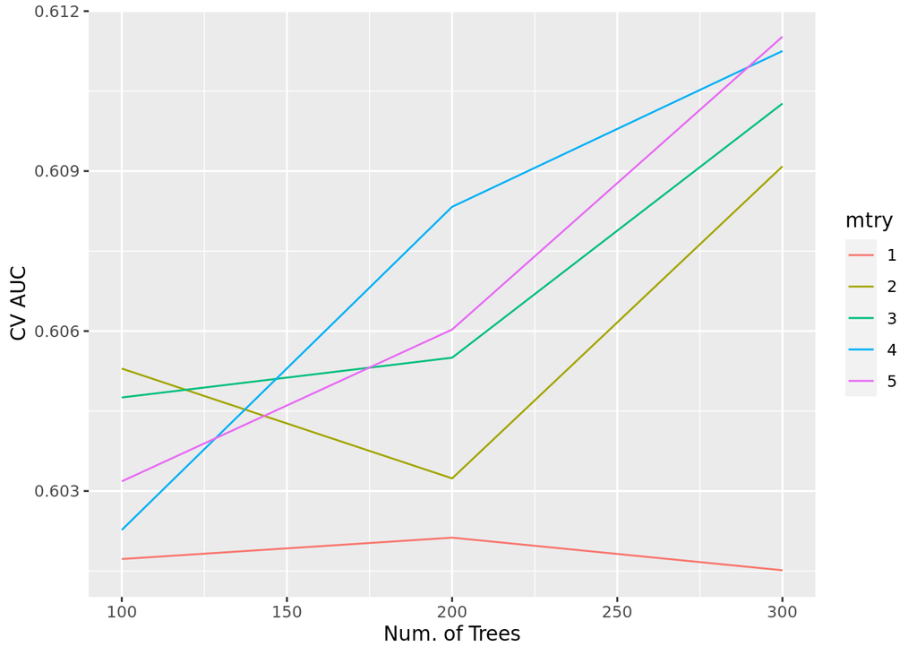

```r
rf_fit %>%
  collect_metrics() %>%
  print(width = Inf) %>%
  filter(.metric == "roc_auc") %>%
  mutate(mtry = as.factor(mtry)) %>%
  ggplot(mapping = aes(x = trees, y = mean, color = mtry)) +
  # geom_point() +
  geom_line() +
  labs(x = "Num. of Trees", y = "CV AUC")
```

```r
rf_fit %>%
  show_best("roc_auc")
```

```
# A tibble: 5 × 8
   mtry trees .metric .estimator  mean     n std_err .config
  <int> <int> <chr>   <chr>      <dbl> <int>   <dbl> <chr>
1     5   300 roc_auc binary     0.612     1      NA Preprocessor1_Model15
2     4   300 roc_auc binary     0.611     1      NA Preprocessor1_Model12
3     3   300 roc_auc binary     0.610     1      NA Preprocessor1_Model09
4     2   300 roc_auc binary     0.609     1      NA Preprocessor1_Model06
5     4   200 roc_auc binary     0.608     1      NA Preprocessor1_Model11
```

```r
best_rf <- rf_fit %>%
  select_best("roc_auc")
best_rf
```

```
# A tibble: 1 × 3
   mtry trees .config
  <int> <int> <chr>
1     5   300 Preprocessor1_Model15
```

```r
# Final workflow
final_wf <- rf_wf %>%
  finalize_workflow(best_rf)
final_wf
```

```
══ Workflow ════════════════════════════════════════════════════════════════════
Preprocessor: Recipe
Model: rand_forest()

── Preprocessor ────────────────────────────────────────────────────────────────
5 Recipe Steps

• step_impute_mean()
• step_impute_knn()
• step_dummy()
• step_zv()
• step_normalize()

── Model ───────────────────────────────────────────────────────────────────────
Random Forest Model Specification (classification)

Main Arguments:
  mtry = 5
  trees = 300

Engine-Specific Arguments:
  importance = impurity

Computational engine: ranger
```

```r
# Fit the whole training set, then predict the test cases
final_fit <-
  final_wf %>%
  last_fit(data_split)
```

```
→ A | warning: skipping variable with zero or non-finite range.
```

```
There were issues with some computations   A: x1
```

```
There were issues with some computations   A: x2
There were issues with some computations   A: x2
```

```r
final_fit
```

```
# Resampling results
# Manual resampling
# A tibble: 1 × 6
  splits                id             .metrics .notes   .predictions .workflow
  <list>                <chr>          <list>   <list>   <list>       <list>
1 <split [36590/36591]> train/test sp… <tibble> <tibble> <tibble>     <workflow>

There were issues with some computations:

  - Warning(s) x2: skipping variable with zero or non-finite range.

Run `show_notes(.Last.tune.result)` for more information.
```

```r
# Test metrics
final_fit %>%
  collect_metrics()
```

```
# A tibble: 2 × 4
  .metric  .estimator .estimate .config
  <chr>    <chr>          <dbl> <chr>
1 accuracy binary         0.584 Preprocessor1_Model1
2 roc_auc  binary         0.613 Preprocessor1_Model1
```

```r
final_tree <- extract_fit_engine(final_fit)
```

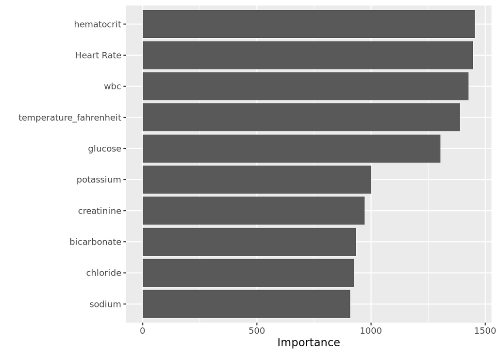

```r
vip(final_tree, num_features = 10)
```

### XG boosting

```r
gb_mod <-
  boost_tree(
    mode = "classification",
    trees = 1000,
    tree_depth = tune(),
    learn_rate = tune()
  ) %>%
  set_engine("xgboost", importance="impurity")%>%
set_mode("classification")
gb_mod
```

```
Boosted Tree Model Specification (classification)

Main Arguments:
  trees = 1000
  tree_depth = tune()
  learn_rate = tune()

Engine-Specific Arguments:
  importance = impurity

Computational engine: xgboost
```

```r
gb_wf <- workflow() %>%
  add_recipe(norm_recipe) %>%
  add_model(gb_mod)
gb_wf
```

```
══ Workflow ════════════════════════════════════════════════════════════════════
Preprocessor: Recipe
Model: boost_tree()

── Preprocessor ────────────────────────────────────────────────────────────────
5 Recipe Steps

• step_impute_mean()
• step_impute_knn()
• step_dummy()
• step_zv()
• step_normalize()

── Model ───────────────────────────────────────────────────────────────────────
Boosted Tree Model Specification (classification)

Main Arguments:
  trees = 1000
  tree_depth = tune()
  learn_rate = tune()

Engine-Specific Arguments:
  importance = impurity

Computational engine: xgboost
```

```r
param_grid <- grid_regular(
  tree_depth(range = c(1L, 3L)),
  learn_rate(range = c(-5, 2), trans = log10_trans()),
  levels = c(3, 10)
  )
param_grid
```

```
# A tibble: 30 × 2
   tree_depth learn_rate
        <int>      <dbl>
 1          1  0.00001
 2          2  0.00001
 3          3  0.00001
 4          1  0.0000599
 5          2  0.0000599
 6          3  0.0000599
 7          1  0.000359
 8          2  0.000359
 9          3  0.000359
10          1  0.00215
# ℹ 20 more rows
```

```r
set.seed(203)

folds <- vfold_cv(mimic_other, v = 5)
folds
```

```
#  5-fold cross-validation
# A tibble: 5 × 2
  splits               id
  <list>               <chr>
1 <split [29272/7318]> Fold1
2 <split [29272/7318]> Fold2
3 <split [29272/7318]> Fold3
4 <split [29272/7318]> Fold4
5 <split [29272/7318]> Fold5
```

```r
gb_fit <- gb_wf %>%
  tune_grid(
    resamples = folds,
    grid = param_grid,
    metrics = metric_set(roc_auc, accuracy)
    )
```

[output not shown]

[output not shown]

[output not shown]

[output not shown]

[output not shown]

[output not shown]

[output not shown]

[output not shown]

[output not shown]

[output not shown]

[output not shown]

[output not shown]

[output not shown]

[output not shown]

[output not shown]

[output not shown]

[output not shown]

[output not shown]

[output not shown]

[output not shown]

[output not shown]

[output not shown]

[output not shown]

[output not shown]

[output not shown]

[output not shown]

[output not shown]

[output not shown]

[output not shown]

[output not shown]

[output not shown]

[output not shown]

[output not shown]

```r
gb_fit
```

```
# Tuning results
# 5-fold cross-validation
# A tibble: 5 × 4
  splits               id    .metrics          .notes
  <list>               <chr> <list>            <list>
1 <split [29272/7318]> Fold1 <tibble [60 × 6]> <tibble [31 × 3]>
2 <split [29272/7318]> Fold2 <tibble [0 × 6]>  <NULL>
3 <split [29272/7318]> Fold3 <tibble [0 × 6]>  <NULL>
4 <split [29272/7318]> Fold4 <tibble [0 × 6]>  <NULL>
5 <split [29272/7318]> Fold5 <tibble [0 × 6]>  <NULL>

There were issues with some computations:

  - Warning(s) x31: skipping variable with zero or non-finite range.

Run `show_notes(.Last.tune.result)` for more information.
```

```
# A tibble: 60 × 8
   tree_depth learn_rate .metric  .estimator  mean     n std_err
        <int>      <dbl> <chr>    <chr>      <dbl> <int>   <dbl>
 1          1  0.00001   accuracy binary     0.545     1      NA
 2          1  0.00001   roc_auc  binary     0.527     1      NA
 3          2  0.00001   accuracy binary     0.560     1      NA
 4          2  0.00001   roc_auc  binary     0.555     1      NA
 5          3  0.00001   accuracy binary     0.565     1      NA
 6          3  0.00001   roc_auc  binary     0.575     1      NA
 7          1  0.0000599 accuracy binary     0.545     1      NA
 8          1  0.0000599 roc_auc  binary     0.541     1      NA
 9          2  0.0000599 accuracy binary     0.560     1      NA
10          2  0.0000599 roc_auc  binary     0.562     1      NA
   .config
   <chr>
 1 Preprocessor1_Model01
 2 Preprocessor1_Model01
 3 Preprocessor1_Model02
 4 Preprocessor1_Model02
 5 Preprocessor1_Model03
 6 Preprocessor1_Model03
 7 Preprocessor1_Model04
 8 Preprocessor1_Model04
 9 Preprocessor1_Model05
10 Preprocessor1_Model05
# ℹ 50 more rows
```

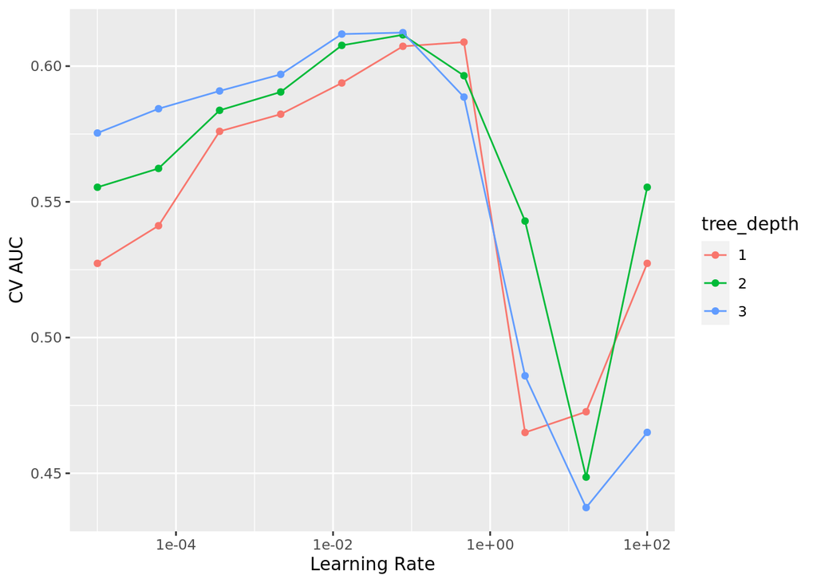

```r
gb_fit %>%
  collect_metrics() %>%
  print(width = Inf) %>%
  filter(.metric == "roc_auc") %>%
  mutate(tree_depth = as.factor(tree_depth)) %>%
  ggplot(mapping = aes(x = learn_rate, y = mean, color = tree_depth)) +
  geom_point() +
  geom_line() +
  labs(x = "Learning Rate", y = "CV AUC") +
  scale_x_log10()
```

```r
gb_fit %>%
  show_best("roc_auc")
```

```
# A tibble: 5 × 8
  tree_depth learn_rate .metric .estimator  mean     n std_err .config
       <int>      <dbl> <chr>   <chr>      <dbl> <int>   <dbl> <chr>
1          3     0.0774 roc_auc binary     0.612     1      NA Preprocessor1_Mo…
2          3     0.0129 roc_auc binary     0.612     1      NA Preprocessor1_Mo…
3          2     0.0774 roc_auc binary     0.612     1      NA Preprocessor1_Mo…
4          1     0.464  roc_auc binary     0.609     1      NA Preprocessor1_Mo…
5          2     0.0129 roc_auc binary     0.608     1      NA Preprocessor1_Mo…
```

```r
best_gb <- gb_fit %>%
  select_best("roc_auc")
best_gb
```

```
# A tibble: 1 × 3
  tree_depth learn_rate .config
       <int>      <dbl> <chr>
1          3     0.0774 Preprocessor1_Model18
```

```r
# Final workflow
final_wf <- gb_wf %>%
  finalize_workflow(best_gb)
final_wf
```

```
══ Workflow ════════════════════════════════════════════════════════════════════
Preprocessor: Recipe
Model: boost_tree()

── Preprocessor ────────────────────────────────────────────────────────────────
5 Recipe Steps

• step_impute_mean()
• step_impute_knn()
• step_dummy()
• step_zv()
• step_normalize()

── Model ───────────────────────────────────────────────────────────────────────
Boosted Tree Model Specification (classification)

Main Arguments:
  trees = 1000
  tree_depth = 3
  learn_rate = 0.0774263682681127

Engine-Specific Arguments:
  importance = impurity

Computational engine: xgboost
```

```r
# Fit the whole training set, then predict the test cases
final_fit <-
  final_wf %>%
  last_fit(data_split)
```

```
→ A | warning: skipping variable with zero or non-finite range.
```

```
There were issues with some computations   A: x1
```

```
There were issues with some computations   A: x2
There were issues with some computations   A: x2
```

```r
final_fit
```

```
# Resampling results
# Manual resampling
# A tibble: 1 × 6
  splits                id             .metrics .notes   .predictions .workflow
  <list>                <chr>          <list>   <list>   <list>       <list>
1 <split [36590/36591]> train/test sp… <tibble> <tibble> <tibble>     <workflow>

There were issues with some computations:

  - Warning(s) x2: skipping variable with zero or non-finite range.

Run `show_notes(.Last.tune.result)` for more information.
```

```r
# Test metrics
final_fit %>%
  collect_metrics()
```

```
# A tibble: 2 × 4
  .metric  .estimator .estimate .config
  <chr>    <chr>          <dbl> <chr>
1 accuracy binary         0.587 Preprocessor1_Model1
2 roc_auc  binary         0.620 Preprocessor1_Model1
```

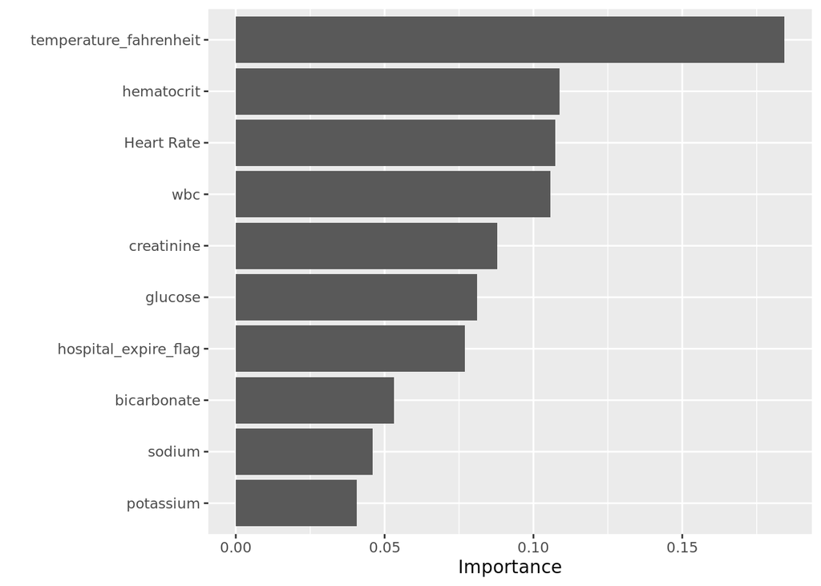

```r
final_tree <- extract_fit_engine(final_fit)
vip(final_tree, num_features = 10)
```

### Logistic regression

```r
logit_mod <-
  logistic_reg(
    penalty = tune(),
    mixture = tune()
  ) |>
  set_engine("glmnet", standardize = FALSE) |>
  print()
```

```
Logistic Regression Model Specification (classification)

Main Arguments:
  penalty = tune()
  mixture = tune()

Engine-Specific Arguments:
  standardize = FALSE

Computational engine: glmnet
```

```r
logit_wf <- workflow() |>
  add_recipe(norm_recipe) |>
  add_model(logit_mod) |>
  print()
```

```
══ Workflow ════════════════════════════════════════════════════════════════════
Preprocessor: Recipe
Model: logistic_reg()

── Preprocessor ────────────────────────────────────────────────────────────────
5 Recipe Steps

• step_impute_mean()
• step_impute_knn()
• step_dummy()
• step_zv()
• step_normalize()

── Model ───────────────────────────────────────────────────────────────────────
Logistic Regression Model Specification (classification)

Main Arguments:
  penalty = tune()
  mixture = tune()

Engine-Specific Arguments:
  standardize = FALSE

Computational engine: glmnet
```

```r
param_grid <- grid_regular(
  penalty(range = c(-6, 3)),
  mixture(),
  levels = c(100, 5)
  ) |>
  print()
```

```
# A tibble: 500 × 2
      penalty mixture
        <dbl>   <dbl>
 1 0.000001         0
 2 0.00000123       0
 3 0.00000152       0
 4 0.00000187       0
 5 0.00000231       0
 6 0.00000285       0
 7 0.00000351       0
 8 0.00000433       0
 9 0.00000534       0
10 0.00000658       0
# ℹ 490 more rows
```

```r
set.seed(203)

folds <- vfold_cv(mimic_other, v = 5)
folds
```

```
#  5-fold cross-validation
# A tibble: 5 × 2
  splits               id
  <list>               <chr>
1 <split [29272/7318]> Fold1
2 <split [29272/7318]> Fold2
3 <split [29272/7318]> Fold3
4 <split [29272/7318]> Fold4
5 <split [29272/7318]> Fold5
```

```r
logit_fit <- logit_wf |>
  tune_grid(
    resamples = folds,
    grid = param_grid,
    metrics = metric_set(roc_auc, accuracy)
    )
```

[output not shown]

[output not shown]

[output not shown]

[output not shown]

[output not shown]

[output not shown]

[output not shown]

```r
logit_fit
```

```
# Tuning results
# 5-fold cross-validation
# A tibble: 5 × 4
  splits               id    .metrics             .notes
  <list>               <chr> <list>               <list>
1 <split [29272/7318]> Fold1 <tibble [1,000 × 6]> <tibble [6 × 3]>
2 <split [29272/7318]> Fold2 <tibble [0 × 6]>     <NULL>
3 <split [29272/7318]> Fold3 <tibble [0 × 6]>     <NULL>
4 <split [29272/7318]> Fold4 <tibble [0 × 6]>     <NULL>
5 <split [29272/7318]> Fold5 <tibble [0 × 6]>     <NULL>

There were issues with some computations:

  - Warning(s) x6: skipping variable with zero or non-finite range.

Run `show_notes(.Last.tune.result)` for more information.
```

```
# A tibble: 1,000 × 8
      penalty mixture .metric  .estimator  mean     n std_err
        <dbl>   <dbl> <chr>    <chr>      <dbl> <int>   <dbl>
 1 0.000001         0 accuracy binary     0.562     1      NA
 2 0.000001         0 roc_auc  binary     0.583     1      NA
 3 0.00000123       0 accuracy binary     0.562     1      NA
 4 0.00000123       0 roc_auc  binary     0.583     1      NA
 5 0.00000152       0 accuracy binary     0.562     1      NA
 6 0.00000152       0 roc_auc  binary     0.583     1      NA
 7 0.00000187       0 accuracy binary     0.562     1      NA
 8 0.00000187       0 roc_auc  binary     0.583     1      NA
 9 0.00000231       0 accuracy binary     0.562     1      NA
10 0.00000231       0 roc_auc  binary     0.583     1      NA
   .config
   <chr>
 1 Preprocessor1_Model001
 2 Preprocessor1_Model001
 3 Preprocessor1_Model002
 4 Preprocessor1_Model002
 5 Preprocessor1_Model003
 6 Preprocessor1_Model003
 7 Preprocessor1_Model004
 8 Preprocessor1_Model004
 9 Preprocessor1_Model005
10 Preprocessor1_Model005
# ℹ 990 more rows
```

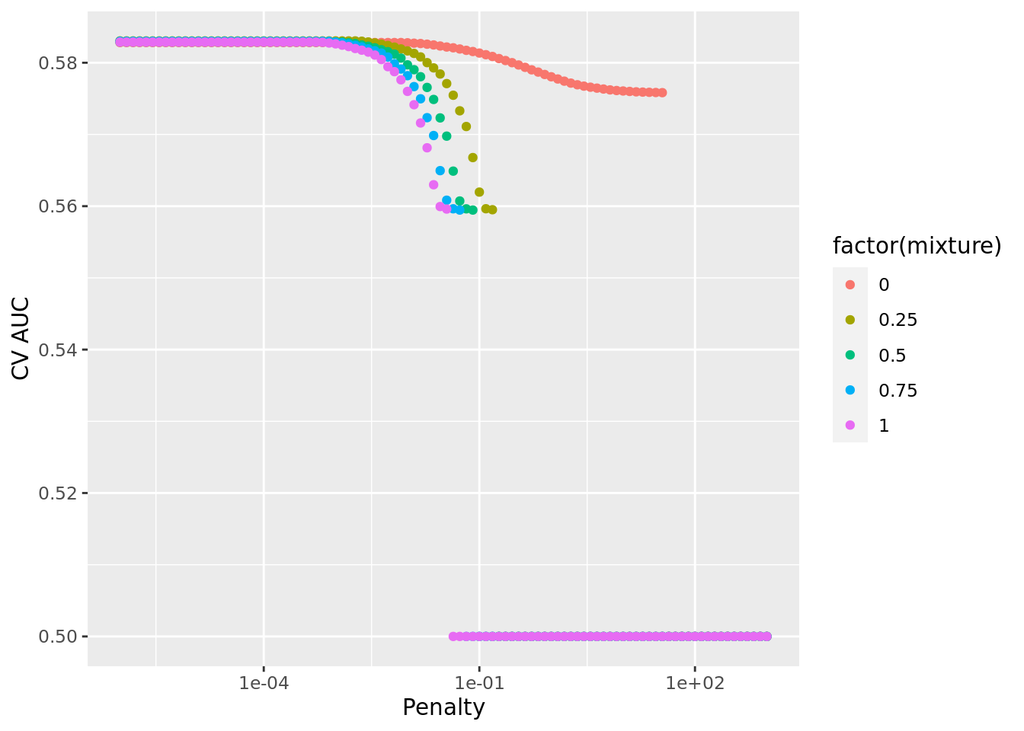

```r
logit_fit |>
  # aggregate metrics from K folds
  collect_metrics() |>
  print(width = Inf) |>
  filter(.metric == "roc_auc") |>
  ggplot(mapping = aes(x = penalty, y = mean, color = factor(mixture))) +
  geom_point() +
  labs(x = "Penalty", y = "CV AUC") +
  scale_x_log10()
```

```r
logit_fit |>
  show_best("roc_auc")
```

```
# A tibble: 5 × 8
     penalty mixture .metric .estimator  mean     n std_err .config
       <dbl>   <dbl> <chr>   <chr>      <dbl> <int>   <dbl> <chr>
1 0.000001      0.25 roc_auc binary     0.583     1      NA Preprocessor1_Model…
2 0.00000123    0.25 roc_auc binary     0.583     1      NA Preprocessor1_Model…
3 0.00000152    0.25 roc_auc binary     0.583     1      NA Preprocessor1_Model…
4 0.00000187    0.25 roc_auc binary     0.583     1      NA Preprocessor1_Model…
5 0.00000231    0.25 roc_auc binary     0.583     1      NA Preprocessor1_Model…
```

```r
best_logit <- logit_fit |>
  select_best("roc_auc")
best_logit
```

```
# A tibble: 1 × 3
   penalty mixture .config
     <dbl>   <dbl> <chr>
1 0.000001    0.25 Preprocessor1_Model101
```

```r
# Final workflow
final_wf <- logit_wf |>
  finalize_workflow(best_logit)
final_wf
```

```
══ Workflow ════════════════════════════════════════════════════════════════════
Preprocessor: Recipe
Model: logistic_reg()

── Preprocessor ────────────────────────────────────────────────────────────────
5 Recipe Steps

• step_impute_mean()
• step_impute_knn()
• step_dummy()
• step_zv()
• step_normalize()

── Model ───────────────────────────────────────────────────────────────────────
Logistic Regression Model Specification (classification)

Main Arguments:
  penalty = 1e-06
  mixture = 0.25

Engine-Specific Arguments:
  standardize = FALSE

Computational engine: glmnet
```

```r
# Fit the whole training set, then predict the test cases
final_fit <-
  final_wf |>
  last_fit(data_split)
```

```
→ A | warning: skipping variable with zero or non-finite range.
```

```
There were issues with some computations   A: x1
```

```
There were issues with some computations   A: x2
There were issues with some computations   A: x2
```

```r
final_fit
```

```
# Resampling results
# Manual resampling
# A tibble: 1 × 6
  splits                id             .metrics .notes   .predictions .workflow
  <list>                <chr>          <list>   <list>   <list>       <list>
1 <split [36590/36591]> train/test sp… <tibble> <tibble> <tibble>     <workflow>

There were issues with some computations:

  - Warning(s) x2: skipping variable with zero or non-finite range.

Run `show_notes(.Last.tune.result)` for more information.
```

```r
# Test metrics
final_fit |>
  collect_metrics()
```

```
# A tibble: 2 × 4
  .metric  .estimator .estimate .config
  <chr>    <chr>          <dbl> <chr>
1 accuracy binary         0.566 Preprocessor1_Model1
2 roc_auc  binary         0.583 Preprocessor1_Model1
```

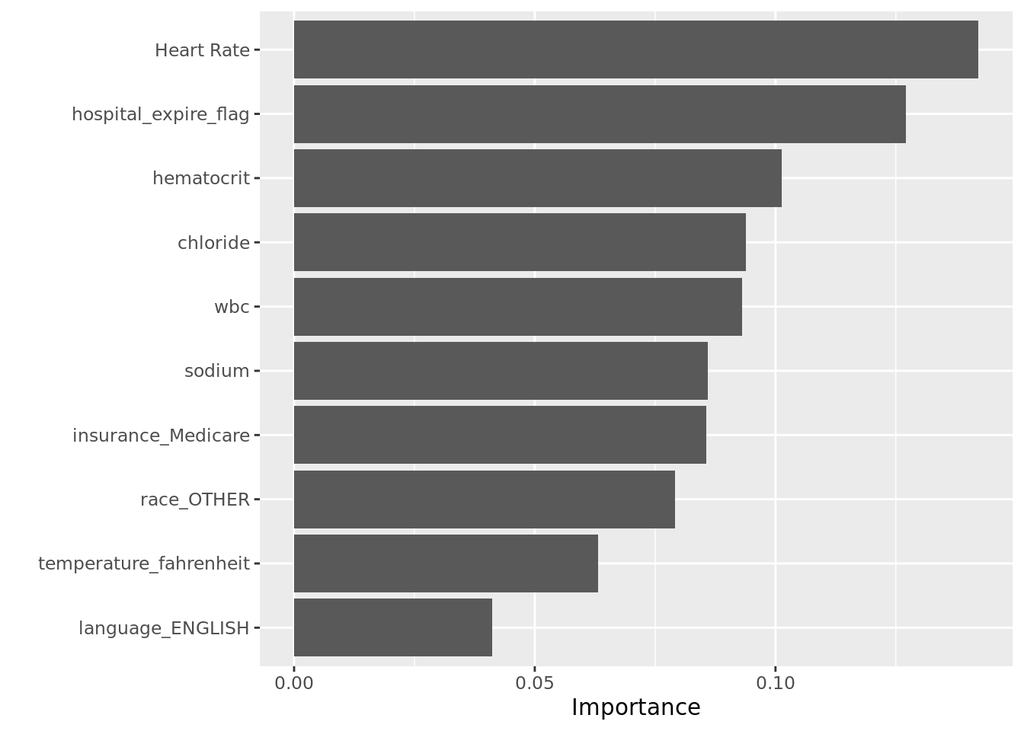

```r
final_tree <- extract_fit_engine(final_fit)
vip(final_tree, num_features = 10)
```

### Model stacking

```r
logit_mod <-
  logistic_reg(
    penalty = tune(),
    mixture = tune()
  ) |>
  set_engine("glmnet", standardize = TRUE)
logit_mod
```

```r
logit_wf <- workflow() |>
  add_recipe(norm_recipe) |>
  add_model(logit_mod)
logit_wf
```

```r
logit_grid <- grid_regular(
  penalty(range = c(-6, 3)),
  mixture(),
  levels = c(100, 5)
  )

logit_res <-
  tune_grid(
    object = logit_wf,
    resamples = folds,
    grid = logit_grid,
    control = control_stack_grid()
  )
logit_res
```

[output not shown]

```r
rf_mod <-
  rand_forest(
    mode = "classification",
    # Number of predictors randomly sampled in each split
    mtry = tune(),
    # Number of trees in ensemble
    trees = tune()
  ) |>
  set_engine("ranger")
rf_mod
```

```r
rf_wf <- workflow() |>
  add_recipe(norm_recipe) |>
  add_model(rf_mod)
rf_wf
```

```r
rf_grid <- grid_regular(
  trees(range = c(100L, 500L)),
  mtry(range = c(1L, 5L)),
  levels = c(5, 5)
  )

rf_res <-
  tune_grid(
    object = rf_wf,
    resamples = folds,
    grid = rf_grid,
    control = control_stack_grid()
  )
rf_res
```

[output not shown]

```r
library(gtsummary)
library(keras)
library(ranger)
library(stacks)
library(tidyverse)
library(yardstick)
```

```r
mimic_model_st <-
  # initialize the stack
  stacks() |>
  # add candidate members
  add_candidates(logit_res) |>
  add_candidates(rf_res) |>
  # determine how to combine their predictions
  blend_predictions(
    penalty = 10^(-6:2),
    metrics = c("roc_auc","accuracy")
    ) |>
  # fit the candidates with nonzero stacking coefficients
  fit_members()
```

```r
mimic_model_st
```

[output not shown]

For my 3 models, I used logistic regression,random forest and Xgboosting to build the model. The ROC and accuracy are as follows:

Random Forest: ROC: 0.6127845, Accuracy: 0.5836408

Xgboosting: ROC: 0.6196825, Accuracy: 0.5866743

Logistic regression: ROC: 0.5829731, Accuracy: 0.5664508

As you can see, the relative performance of the models is similar. The Xgboosting model has the highest ROC and accuracy, followed by the random forest model. The logistic regression model has the lowest ROC and accuracy. As in the vip graph, the most important features relatively in predicting long ICU stays are “Heart Rate”, “hematocrit”.

Overall, we should choose the Xgboosting model as the best model because it has the highest ROC and accuracy. The random forest model is also a good choice because it has a similar performance to the Xgboosting model and is more interpretable. The logistic regression model is the least desirable because it has the lowest ROC and accuracy.